# Revisão das variáveis selecionadas

## Lendo a base

```r
df <- read.csv2(file = "df.csv")
```

Filtrando os dados para pegar apenas idosos (idade >=60)

```r
df <-
  df |>
  dplyr::filter(RIDAGEYR >= 60)
```

## Step 1- Verificar se extrai as variáveis solicitadas

Abaixo estão todas as variáveis extrai de acordo com o documento que você me enviou.

Cheque se extrai todas.

```r
colnames(df)
```

```
 [1] "SEQN"     "HUQ010"   "HUQ071"   "HUD080"   "SDDSRVYR" "RIAGENDR"
 [7] "RIDAGEYR" "RIDRETH1" "DMDEDUC2" "DMDMARTL" "INDFMIN2" "WTINT2YR"
[13] "WTMEC2YR" "PAQ605"   "PAQ610"   "PAD615"   "PAQ620"   "PAQ625"
[19] "PAD630"   "PAQ635"   "PAQ640"   "PAD645"   "PAQ650"   "PAQ655"
[25] "PAD660"   "PAQ665"   "PAQ670"   "PAD675"   "PAD680"   "CDQ010"
[31] "CDQ001"   "DIQ010"   "DIQ050"   "RXDUSE"   "RXDCOUNT" "SMQ020"
[37] "SMD030"   "SMQ040"   "SMQ050Q"  "SMD641"   "SMD650"   "MCQ160B"
[43] "MCQ160C"  "MCQ160D"  "MCQ160E"  "MCQ160F"  "MCQ160O"  "MCQ080"
[49] "MCQ160L"  "MCQ220"   "KIQ022"   "WTDRD1"   "DR1TKCAL" "DR1TPROT"
[55] "DR1TCARB" "DR1TSUGR" "DR1TFIBE" "DR1TTFAT" "DR1TSFAT" "DR1TMFAT"
[61] "DR1TPFAT" "DR1TCHOL" "WTDR2D"   "DR2TKCAL" "DR2TPROT" "DR2TCARB"
[67] "DR2TSUGR" "DR2TFIBE" "DR2TTFAT" "DR2TSFAT" "DR2TMFAT" "DR2TPFAT"
[73] "DR2TCHOL" "BMXWT"    "BMXHT"    "BPXSY1"   "BPXDI1"   "BPXSY2"
[79] "BPXDI2"   "BPXSY3"   "BPXDI3"
```

- SDDSRVYR: Data release cycle;

Essas variáveis são necessárias para fazer o *sample* *design*, procedimento de amostragem que é realizado para manter a amostra representativa da população americana.

## Tamanho da amostra

O tamanho da amostra esta em 4051. Lembrando que esse “n” consiste de sujeitos com idade igual ou superior a 60 .

# PONTO IMPORTANTE

## Dados ausentes

Primeiramente, observe a figura abaixo que apresenta os percentual de dados faltantes para cada variável.

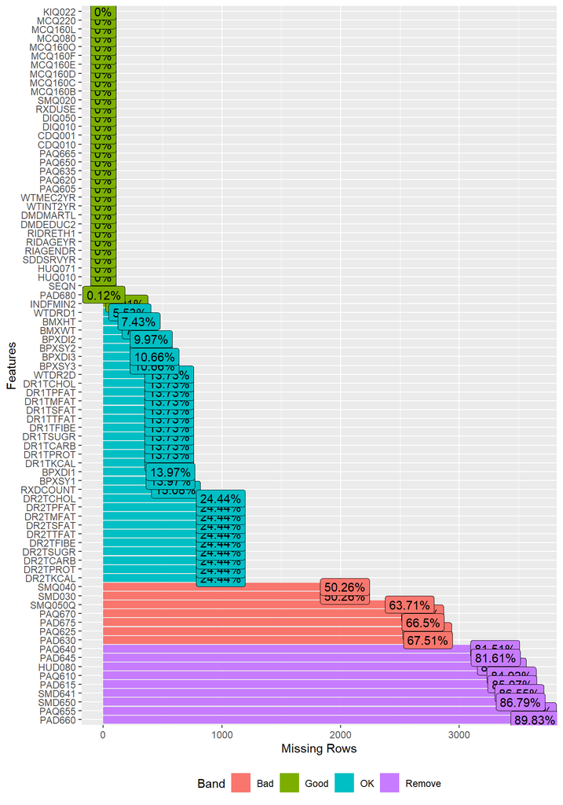

```r
DataExplorer::plot_missing(df)
```

Repare nas colunas vermelha e lilás. Para essas varáveis, a quantidade de dados faltantes é elevada e, se forem fundamentais para o seu trabalho, não será possível realizar as analises devido ao pequeno tamanho amostral.

Dê uma olhada na tabela abaixo (50 primeiras linhas) a quatidade de dado faltante (expresso como NA):

```r
knitr::kable(df[1:50,])
```

| SEQN | HUQ010 | HUQ071 | HUD080 | SDDSRVYR | RIAGENDR | RIDAGEYR | RIDRETH1 | DMDEDUC2 | DMDMARTL | INDFMIN2 | WTINT2YR | WTMEC2YR | PAQ605 | PAQ610 | PAD615 | PAQ620 | PAQ625 | PAD630 | PAQ635 | PAQ640 | PAD645 | PAQ650 | PAQ655 | PAD660 | PAQ665 | PAQ670 | PAD675 | PAD680 | CDQ010 | … |
| --- | --- | --- | --- | --- | --- | --- | --- | --- | --- | --- | --- | --- | --- | --- | --- | --- | --- | --- | --- | --- | --- | --- | --- | --- | --- | --- | --- | --- | --- | --- |
| 83732 | 3 | 2 | NA | 9 | 1 | 62 | 3 | 5 | 1 | 10 | 134671.370 | 135629.507 | 2 | NA | NA | 1 | 5 | 10 | 2 | NA | NA | 2 | NA | NA | 1 | 6 | 30 | 480 | 1 | … |
| 83734 | 4 | 2 | NA | 9 | 1 | 78 | 3 | 3 | 1 | 5 | 12400.009 | 12575.839 | 2 | NA | NA | 1 | 4 | 240 | 2 | NA | NA | 2 | NA | NA | 2 | NA | NA | 480 | 1 | … |
| 83737 | 3 | 2 | NA | 9 | 2 | 72 | 1 | 2 | 4 | 14 | 11252.312 | 10878.684 | 2 | NA | NA | 2 | NA | NA | 2 | NA | NA | 2 | NA | NA | 2 | NA | NA | 10 | 2 | … |
| 83754 | 2 | 2 | NA | 9 | 2 | 67 | 2 | 5 | 1 | 6 | 10495.866 | 10191.914 | 2 | NA | NA | 2 | NA | NA | 2 | NA | NA | 2 | NA | NA | 1 | 5 | 35 | 360 | 1 | … |
| 83755 | 2 | 2 | NA | 9 | 1 | 67 | 4 | 5 | 2 | 5 | 14080.096 | 13991.639 | 2 | NA | NA | 2 | NA | NA | 1 | 2 | 180 | 2 | NA | NA | 1 | 2 | 90 | 180 | 1 | … |
| 83758 | 2 | 2 | NA | 9 | 1 | 80 | 3 | 5 | 2 | 9 | 30375.766 | 0.000 | 2 | NA | NA | 2 | NA | NA | 2 | NA | NA | 2 | NA | NA | 2 | NA | NA | 600 | 2 | … |
| 83773 | 2 | 2 | NA | 9 | 2 | 80 | 3 | 3 | 2 | 7 | 37582.053 | 39939.419 | 2 | NA | NA | 2 | NA | NA | 2 | NA | NA | 2 | NA | NA | 2 | NA | NA | 120 | 2 | … |
| 83775 | 3 | 2 | NA | 9 | 2 | 69 | 2 | 1 | 4 | 2 | 7250.103 | 8799.981 | 2 | NA | NA | 2 | NA | NA | 1 | 7 | 90 | 2 | NA | NA | 1 | 7 | 90 | 480 | 2 | … |
| 83785 | 3 | 2 | NA | 9 | 2 | 60 | 2 | 5 | 3 | 15 | 10495.866 | 10191.914 | 2 | NA | NA | 2 | NA | NA | 2 | NA | NA | 2 | NA | NA | 1 | 3 | 60 | 300 | 2 | … |
| 83787 | 3 | 2 | NA | 9 | 2 | 68 | 1 | 1 | 3 | 4 | 8842.350 | 10732.607 | 2 | NA | NA | 2 | NA | NA | 2 | NA | NA | 2 | NA | NA | 2 | NA | NA | 60 | 1 | … |
| 83788 | 1 | 2 | NA | 9 | 2 | 69 | 3 | 4 | 1 | 7 | 50114.532 | 49234.971 | 1 | 3 | 240 | 1 | 4 | 180 | 2 | NA | NA | 2 | NA | NA | 2 | NA | NA | 120 | 2 | … |
| 83789 | 3 | 2 | NA | 9 | 1 | 66 | 3 | 5 | 6 | 9 | 181684.439 | 181461.242 | 2 | NA | NA | 1 | 3 | 60 | 2 | NA | NA | 2 | NA | NA | 1 | 7 | 40 | 300 | 2 | … |
| 83791 | 4 | 2 | NA | 9 | 2 | 80 | 3 | 2 | 1 | 12 | 59524.529 | 62213.984 | 2 | NA | NA | 2 | NA | NA | 2 | NA | NA | 2 | NA | NA | 2 | NA | NA | 120 | 2 | … |
| 83801 | 3 | 2 | NA | 9 | 2 | 80 | 3 | 5 | 1 | 77 | 59053.937 | 61722.130 | 2 | NA | NA | 2 | NA | NA | 2 | NA | NA | 2 | NA | NA | 2 | NA | NA | 540 | 2 | … |
| 83812 | 2 | 2 | NA | 9 | 2 | 68 | 1 | 3 | 1 | 15 | 10255.968 | 9985.162 | 2 | NA | NA | 2 | NA | NA | 2 | NA | NA | 2 | NA | NA | 2 | NA | NA | 180 | 2 | … |
| 83818 | 3 | 1 | 1 | 9 | 2 | 80 | 2 | 1 | 2 | 3 | 7124.422 | 8609.625 | 2 | NA | NA | 2 | NA | NA | 1 | 5 | 30 | 2 | NA | NA | 2 | NA | NA | 300 | 2 | … |
| 83820 | 2 | 2 | NA | 9 | 1 | 70 | 3 | 5 | 6 | 8 | 56259.362 | 57057.111 | 2 | NA | NA | 1 | 5 | 300 | 2 | NA | NA | 2 | NA | NA | 1 | 4 | 180 | 240 | 2 | … |
| 83821 | 5 | 2 | NA | 9 | 1 | 80 | 3 | 1 | 2 | 3 | 15513.742 | 16856.902 | 2 | NA | NA | 2 | NA | NA | 2 | NA | NA | 2 | NA | NA | 2 | NA | NA | 420 | 1 | … |
| 83827 | 2 | 2 | NA | 9 | 1 | 61 | 4 | 3 | 1 | 10 | 14080.096 | 15028.727 | 2 | NA | NA | 2 | NA | NA | 2 | NA | NA | 2 | NA | NA | 1 | 2 | 45 | 540 | 2 | … |
| 83834 | 3 | 2 | NA | 9 | 1 | 69 | 4 | 3 | 5 | 3 | 11885.517 | 12267.521 | 2 | NA | NA | 2 | NA | NA | 2 | NA | NA | 2 | NA | NA | 1 | 3 | 20 | 420 | 1 | … |
| 83843 | 3 | 1 | 1 | 9 | 1 | 80 | 3 | 4 | 1 | 8 | 17184.348 | 18517.465 | 2 | NA | NA | 2 | NA | NA | 2 | NA | NA | 2 | NA | NA | 2 | NA | NA | 600 | 2 | … |
| 83849 | 4 | 1 | 4 | 9 | 1 | 71 | 2 | 4 | 1 | 6 | 11138.899 | 11258.827 | 2 | NA | NA | 2 | NA | NA | 1 | 5 | 15 | 2 | NA | NA | 1 | 2 | 10 | 180 | 2 | … |
| 83861 | 4 | 2 | NA | 9 | 1 | 80 | 3 | 5 | 3 | 8 | 43427.972 | 0.000 | 2 | NA | NA | 2 | NA | NA | 1 | 7 | 60 | 1 | 7 | 60 | 2 | NA | NA | 180 | 1 | … |
| 83869 | 4 | 2 | NA | 9 | 2 | 67 | 3 | 5 | 3 | 4 | 37858.790 | 37505.347 | 2 | NA | NA | 1 | 7 | 30 | 2 | NA | NA | 2 | NA | NA | 2 | NA | NA | 240 | 1 | … |
| 83872 | 5 | 2 | NA | 9 | 1 | 63 | 1 | 3 | 2 | 99 | 8012.501 | 7738.996 | 1 | 7 | 240 | 1 | 5 | 240 | 1 | 3 | 30 | 2 | NA | NA | 2 | NA | NA | 360 | 1 | … |
| 83876 | 2 | 2 | NA | 9 | 2 | 71 | 3 | 3 | 3 | 2 | 45307.965 | 51541.657 | 2 | NA | NA | 2 | NA | NA | 2 | NA | NA | 2 | NA | NA | 2 | NA | NA | 480 | 2 | … |
| 83880 | 4 | 2 | NA | 9 | 2 | 79 | 3 | 1 | 1 | 3 | 44576.005 | 46534.060 | 2 | NA | NA | 2 | NA | NA | 1 | 2 | 12 | 2 | NA | NA | 2 | NA | NA | 240 | 1 | … |
| 83883 | 4 | 2 | NA | 9 | 2 | 80 | 1 | 2 | 5 | 2 | 12211.035 | 11641.229 | 2 | NA | NA | 2 | NA | NA | 2 | NA | NA | 2 | NA | NA | 1 | 4 | 30 | 240 | 2 | … |
| 83884 | 4 | 1 | 1 | 9 | 1 | 61 | 1 | 3 | 1 | 4 | 8261.763 | 8113.690 | 2 | NA | NA | 2 | NA | NA | 2 | NA | NA | 2 | NA | NA | 2 | NA | NA | 480 | 1 | … |
| 83886 | 2 | 2 | NA | 9 | 1 | 74 | 3 | 5 | 1 | 6 | 18954.717 | 18906.150 | 2 | NA | NA | 2 | NA | NA | 1 | 7 | 60 | 1 | 5 | 30 | 1 | 4 | 60 | 480 | 2 | … |
| 83893 | 3 | 2 | NA | 9 | 2 | 68 | 1 | 1 | 1 | 4 | 9256.485 | 0.000 | 2 | NA | NA | 2 | NA | NA | 2 | NA | NA | 2 | NA | NA | 1 | 7 | 30 | 120 | 1 | … |
| 83894 | 3 | 2 | NA | 9 | 1 | 60 | 4 | 3 | 1 | 8 | 11029.710 | 14849.610 | 2 | NA | NA | 1 | 7 | 240 | 2 | NA | NA | 2 | NA | NA | 2 | NA | NA | 180 | 1 | … |
| 83895 | 4 | 1 | 3 | 9 | 2 | 80 | 3 | 3 | 2 | 4 | 36609.714 | 38906.089 | 2 | NA | NA | 2 | NA | NA | 2 | NA | NA | 2 | NA | NA | 2 | NA | NA | 600 | 2 | … |
| 83904 | 4 | 2 | NA | 9 | 2 | 80 | 4 | 2 | 1 | 3 | 16549.772 | 0.000 | 1 | 7 | 9999 | 1 | 7 | 9999 | 2 | NA | NA | 2 | NA | NA | 2 | NA | NA | 120 | 1 | … |
| 83915 | 4 | 1 | 2 | 9 | 1 | 71 | 1 | 4 | 6 | 6 | 12060.355 | 12158.220 | 2 | NA | NA | 2 | NA | NA | 2 | NA | NA | 2 | NA | NA | 2 | NA | NA | 240 | 2 | … |
| 83920 | 4 | 2 | NA | 9 | 2 | 68 | 1 | 1 | 1 | 3 | 9719.310 | 9306.463 | 2 | NA | NA | 2 | NA | NA | 2 | NA | NA | 2 | NA | NA | 2 | NA | NA | 240 | 2 | … |
| 83925 | 3 | 2 | NA | 9 | 2 | 74 | 2 | 3 | 2 | 8 | 11817.131 | 12379.093 | 2 | NA | NA | 2 | NA | NA | 2 | NA | NA | 2 | NA | NA | 2 | NA | NA | 360 | 2 | … |
| 83926 | 3 | 2 | NA | 9 | 1 | 66 | 3 | 4 | 1 | 9 | 114108.867 | 113023.592 | 1 | 3 | 240 | 1 | 2 | 120 | 2 | NA | NA | 2 | NA | NA | 2 | NA | NA | 300 | 2 | … |
| 83927 | 3 | 1 | 1 | 9 | 2 | 66 | 5 | 5 | 1 | 10 | 19836.672 | 0.000 | 2 | NA | NA | 2 | NA | NA | 2 | NA | NA | 1 | 2 | 30 | 1 | 2 | 30 | 540 | 2 | … |
| 83928 | 4 | 2 | NA | 9 | 2 | 62 | 1 | 3 | 1 | NA | 9632.696 | 9223.528 | 2 | NA | NA | 2 | NA | NA | 2 | NA | NA | 2 | NA | NA | 2 | NA | NA | 9999 | 2 | … |
| 83932 | 2 | 2 | NA | 9 | 2 | 80 | 3 | 4 | 1 | 8 | 47792.367 | 50790.182 | 2 | NA | NA | 1 | 2 | 60 | 2 | NA | NA | 2 | NA | NA | 1 | 5 | 40 | 360 | 2 | … |
| 83937 | 2 | 2 | NA | 9 | 2 | 75 | 5 | 1 | 2 | 8 | 20928.332 | 22485.677 | 2 | NA | NA | 1 | 7 | 180 | 1 | 7 | 30 | 2 | NA | NA | 2 | NA | NA | 240 | 2 | … |
| 83941 | 5 | 1 | 2 | 9 | 1 | 71 | 2 | 3 | 1 | NA | 7167.008 | 7124.585 | 1 | 3 | 30 | 1 | 3 | 15 | 1 | 3 | 10 | 1 | 6 | 20 | 1 | 6 | 30 | 180 | 1 | … |
| 83944 | 2 | 2 | NA | 9 | 1 | 75 | 4 | 4 | 6 | 4 | 12242.238 | 12818.137 | 2 | NA | NA | 2 | NA | NA | 1 | 1 | 15 | 2 | NA | NA | 2 | NA | NA | 480 | 1 | … |
| 83949 | 3 | 2 | NA | 9 | 2 | 78 | 3 | 3 | 2 | 6 | 48991.552 | 51570.787 | 2 | NA | NA | 2 | NA | NA | 2 | NA | NA | 2 | NA | NA | 2 | NA | NA | 720 | 2 | … |
| 83964 | 3 | 2 | NA | 9 | 2 | 72 | 5 | 2 | 1 | 10 | 22245.321 | 23978.556 | 2 | NA | NA | 2 | NA | NA | 2 | NA | NA | 2 | NA | NA | 1 | 1 | 10 | 240 | 2 | … |
| 83973 | 2 | 2 | NA | 9 | 1 | 63 | 3 | 5 | 1 | 15 | 163538.991 | 161983.592 | 2 | NA | NA | 2 | NA | NA | 2 | NA | NA | 1 | 4 | 30 | 1 | 2 | 60 | 300 | 2 | … |
| 83975 | 3 | 2 | NA | 9 | 2 | 65 | 2 | 3 | 1 | 14 | 10495.866 | 10191.914 | 2 | NA | NA | 2 | NA | NA | 2 | NA | NA | 2 | NA | NA | 2 | NA | NA | 300 | 2 | … |
| 83976 | 2 | 2 | NA | 9 | 1 | 80 | 3 | 4 | 2 | 5 | 42153.093 | 45423.218 | 2 | NA | NA | 2 | NA | NA | 2 | NA | NA | 2 | NA | NA | 2 | NA | NA | 360 | 2 | … |
| 83977 | 3 | 2 | NA | 9 | 2 | 80 | 3 | 3 | 1 | 7 | 55881.166 | 58406.005 | 2 | NA | NA | 2 | NA | NA | 2 | NA | NA | 2 | NA | NA | 2 | NA | NA | 480 | 1 | … |

# O QUE PRECISA FAZER!?

## Step 2- Renomear as variáveis

Precisamos renomear as variáveis para que possamos trabalhar com elas com mais facilidade na fase de modelagem.

Faça um documento em word seguindo o formato;

(

novo_nome = nome_antigo,

…

)

*IMPORTANTE: Não use caracteres especiais, letras maiúsculas nem hífen. Tente usar um formato curto e se precisar use underline.*

## Step 2 - Checar as variáveis 1 a 1

Verifique porque a quantidade de dados faltantes. Em particular, para a variável que é desfecho do seu trabalho;

*Obs* Para as variáveis de atividade física, eu imagino que as variáveis com grande número de dados faltantes não são determinantes para a quantificar o nível de atividade física. Mas veja certinho o que é cada uma delas.

## Step 3 - Precisa criar alguma variável?

Neste etapa é quando devemos criar alguma variável. Você pretende criar alguma?

Por exemplo, se você pegou as variáveis peso e estatura, pode querer calcular o IMC.

Precisa me indicar as variáveis que deseja que calcula e, claro, com o cálculo que devo utilizar.